# Predictive Factors of Profitability in Movies

Team 07: [individual names redacted]

Last updated on [date redacted]

# 1. Introduction

This study aims to understand how and whether rotten tomatoes ratings will influence the profitability of Hollywood movies. To be specific the question is whether the ratings and genre of movies will affect the percentage of profitability for Hollywood movies.

We have data from different genres of various profitable Hollywood movies in 2011 and its corresponding variables that describe it. The data set contains the rotten tomatoes ratings and profitability of the movies, both of which are measured in percentage. The data was obtained from the orignial source itself which was the “information is beautiful” website, in which you can access it through a title named “Hollywood Budgets”[^1].

We decided to focus on the Profitability as our outcome variable in order to make this report more concise. We included two explanatory variables in this analysis: the rotten tomatoes ratings, and genre of movies, five levels, “Action”, “Comedy”, “Drama”, “Horror” and “Other”, which was 10 levels before data wrangling. We had to remove the first row of the data set because it displayed only the units of measurement of the columns. We had to remove the percentage sign from the values under the “probability” variable and convert the values of “probability” and “rotten tomatoes” variables from string to numerical to conduct exploratory analysis.

Here is a snapshot of 5 randomly chosen rows of the data set we’ll use:

| film | profitability | rotten_tomatoes | genre | lead_studio |
| --- | --- | --- | --- | --- |
| Immortals | 302.54 | 36 | Action | Relativity Media |
| J.Edgar | 241.73 | 42 | Drama | Warner Bros |
| Sucker Punch | 109.50 | 23 | Action | Legendary Pictures |
| The Help | 866.56 | 75 | Drama | DreamWorks Pictures |
| Paul | 244.96 | 72 | Comedy | Relativity |

# 2. Exploratory data analysis

We had an original sample size of 143 movies. These were observations, where there were no information available in its columns like “profitability”, “genre”, “rotten_tomatoes”, and “lead_studio”. The observation that can be identified as “Average” in the “film” category, is not a film but the row used to calculate the average of the numerical variables. This observation was not useful as it only partly collected average values of the whole data set and was placed in between categorical values which could be easily misunderstood. Also the first row of the original data only displayed the corresponding units of measurement of the variables. Therefore, those 4 observations had to be ignored for further exploratory and numerical analysis. Unfortunately, no information was provided as to why some movies had missing values and most didn’t, so we cannot comment on the impact dropping these missing cases has on our results.

Our total sample size was 139 (Table 1). The mean of the profitability of movies was greatest for Horror movies (n = 16, $\bar{x}$ = 852.9, sd = 1795.1), and lowest for Action movies (n = 31, $\bar{x}$ = 240.4, sd = 152.5).

The rotten tomatoes ratings of movies ranged from 4% to 97% ($\bar{x}$ = 54.6, sd = 26.8).

Table 1. Summary statistics of Profitability for Action, Horror, Comedy, Drama and Other genre of movies.

| genre | n | mean | median | sd | min | max |
| --- | --- | --- | --- | --- | --- | --- |
| Action | 31 | 240.4348 | 221.010 | 152.4513 | 3.68 | 576.30 |
| Comedy | 29 | 317.4962 | 231.000 | 261.3401 | 18.17 | 1080.98 |
| Drama | 25 | 284.9384 | 240.030 | 276.2304 | 30.33 | 886.22 |
| Horror | 16 | 852.9456 | 227.565 | 1795.0563 | 23.17 | 6467.27 |
| Other | 38 | 388.2813 | 337.970 | 230.2891 | 25.99 | 1073.21 |

In our histogram, the distribution is right skewed. Most films are having profitability between 0% and approximately 1000 % but there are two outliers with relatively high profitability and they are Paranormal Activity 3 with a profitability of over 4000% and Insidious with over 6000% profitability with both being horror movies.

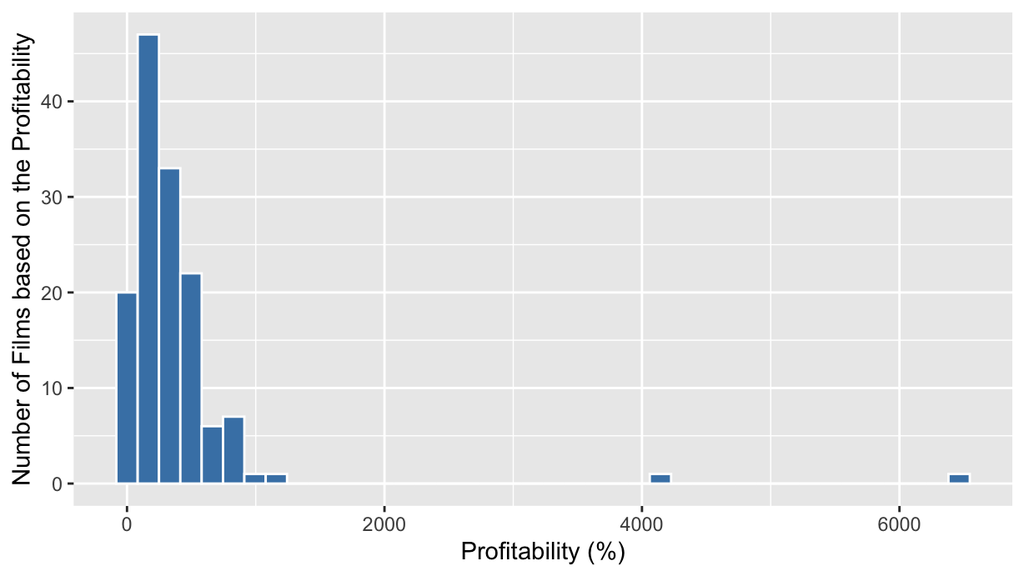

Figure 1. Distribution of the Profitabilty of Movies.

There is slightly positive correlation and linear relationship between profitability and Rotten Tomatoes ratings of movies which means the higher the rotten tomatoes scores of the movie the more likely the movie is to be profitable. Consistent with this relationship is this weak positive correlation coefficient of 0.16.

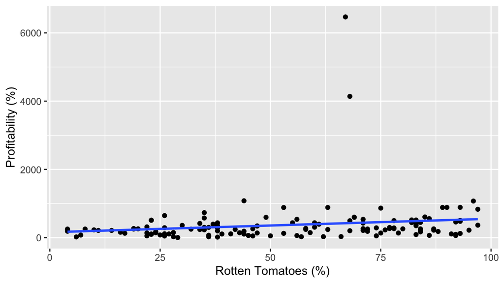

Figure 2. Scatterplot of relationship between Profitability and Rotten Tomatoes Rating of Movies.

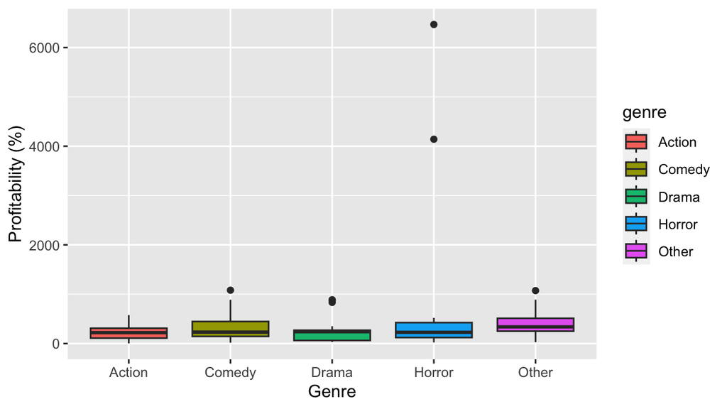

Figure 3. Boxplot of relationship between Profitability and Genre of Movies.

This is the same as the previous scatter plot but now each genre has its own line of best fit and the data points are colored by their genre which is shown in the legend. Based on the genre “Horror”, it has the most positive linear relationship which could be due to its high value outliers. All the other genres have their slopes roughly similar.

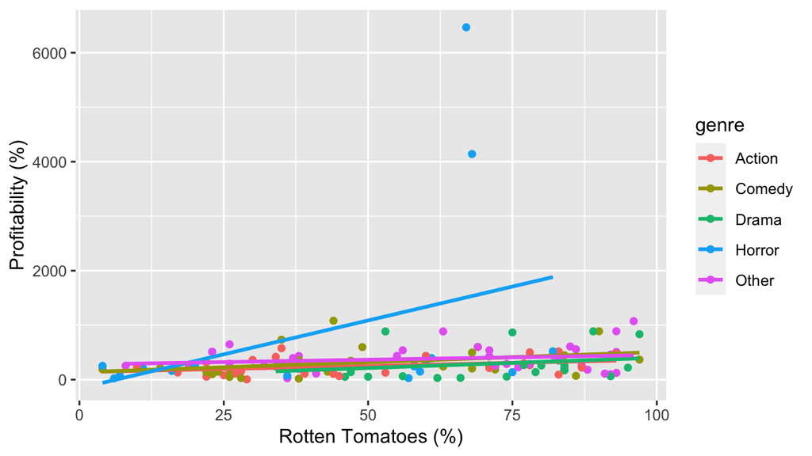

Figure 4. Colored scatterplot of relationship between Profitability and both Rotten Tomatoes Ratings and Genre of Movies.